# Which Features of the House Have the Most Influence on its Sale Price?

# 1. **Model Completeness**

The histogram of residuals along with the residuals’ probability density plot are shown below; they support the normality assumption of the residuals.

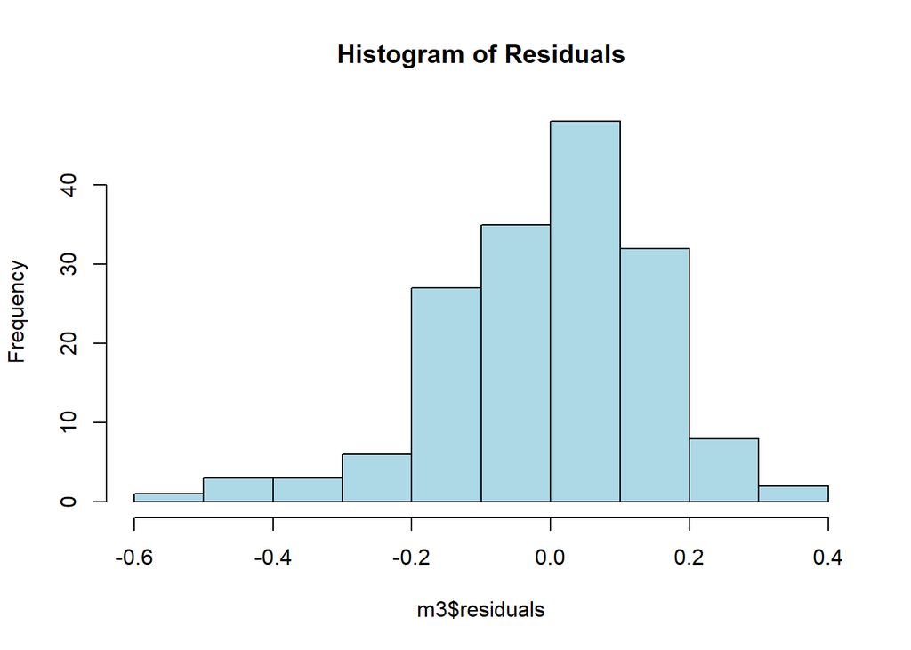

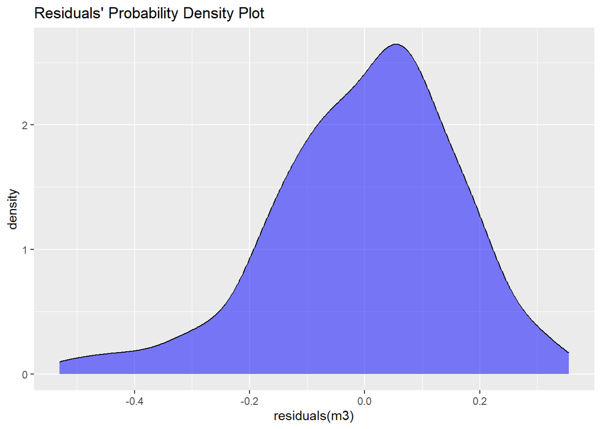

The fitted-versus-residual plot looks like noise with no systematic pattern, and this supports the assumption of normality and constant variance of the residuals.

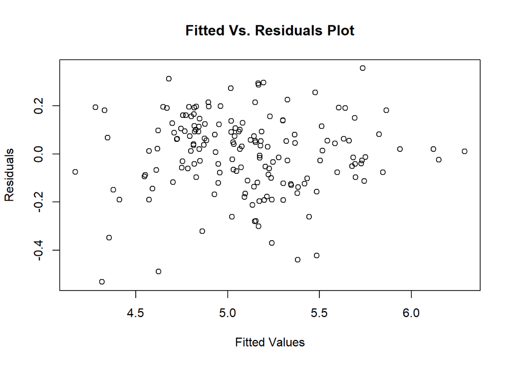

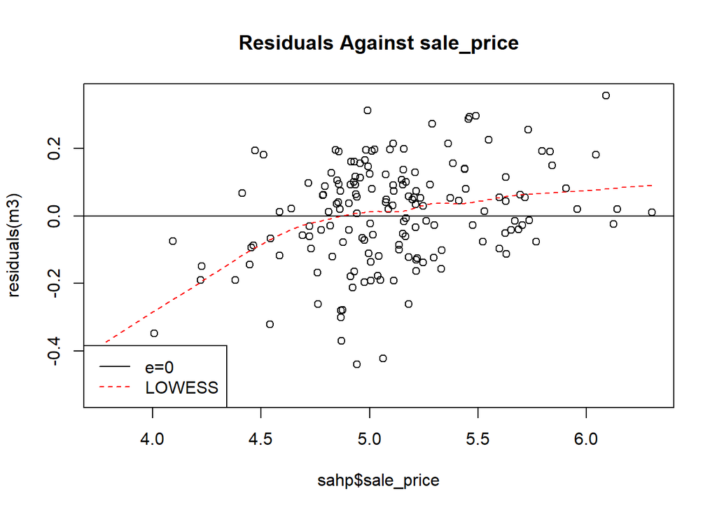

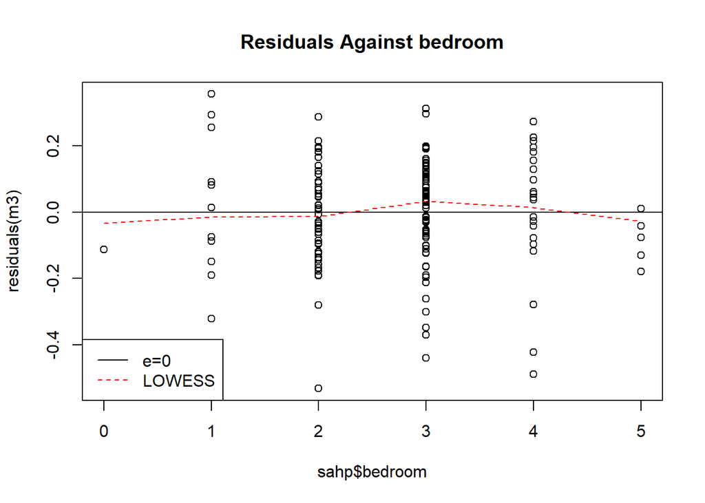

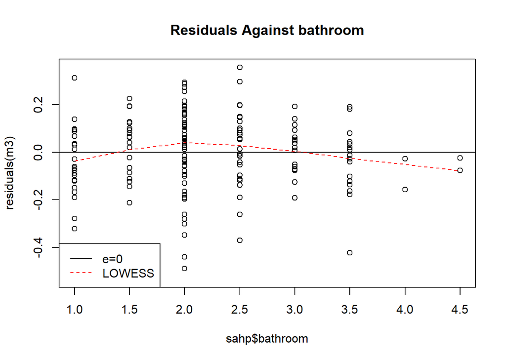

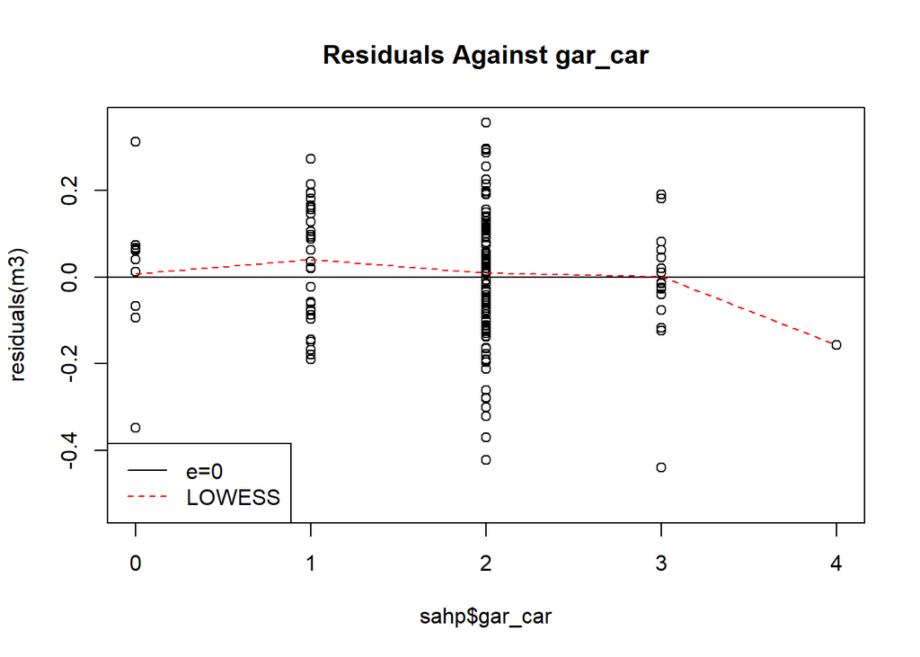

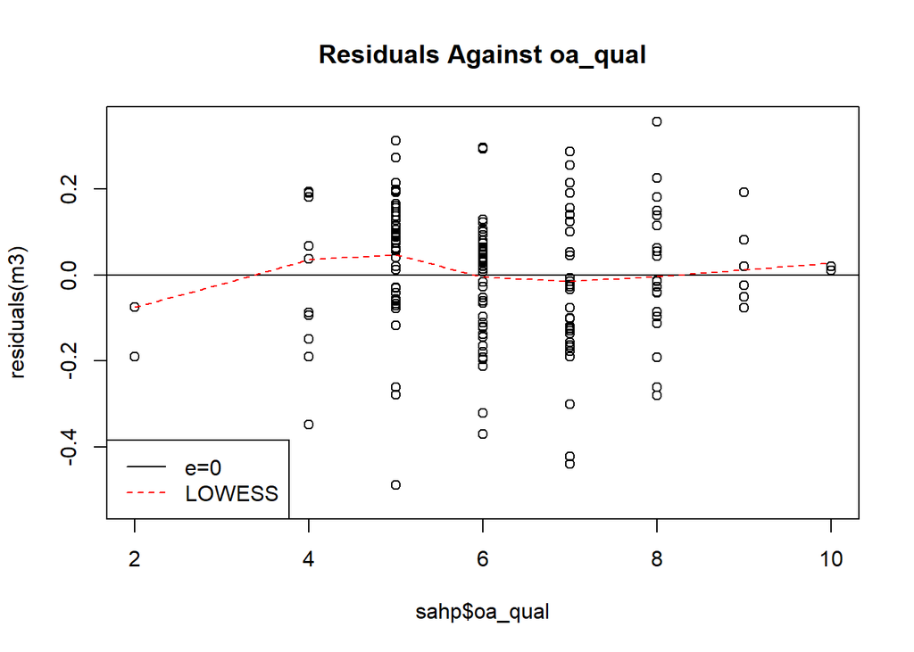

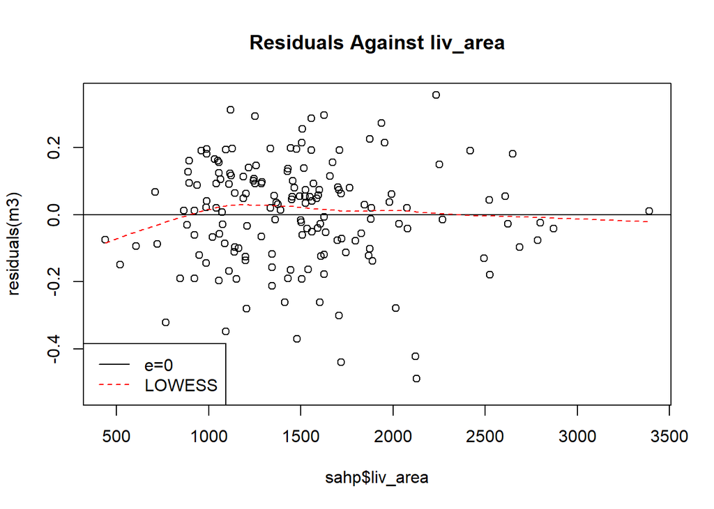

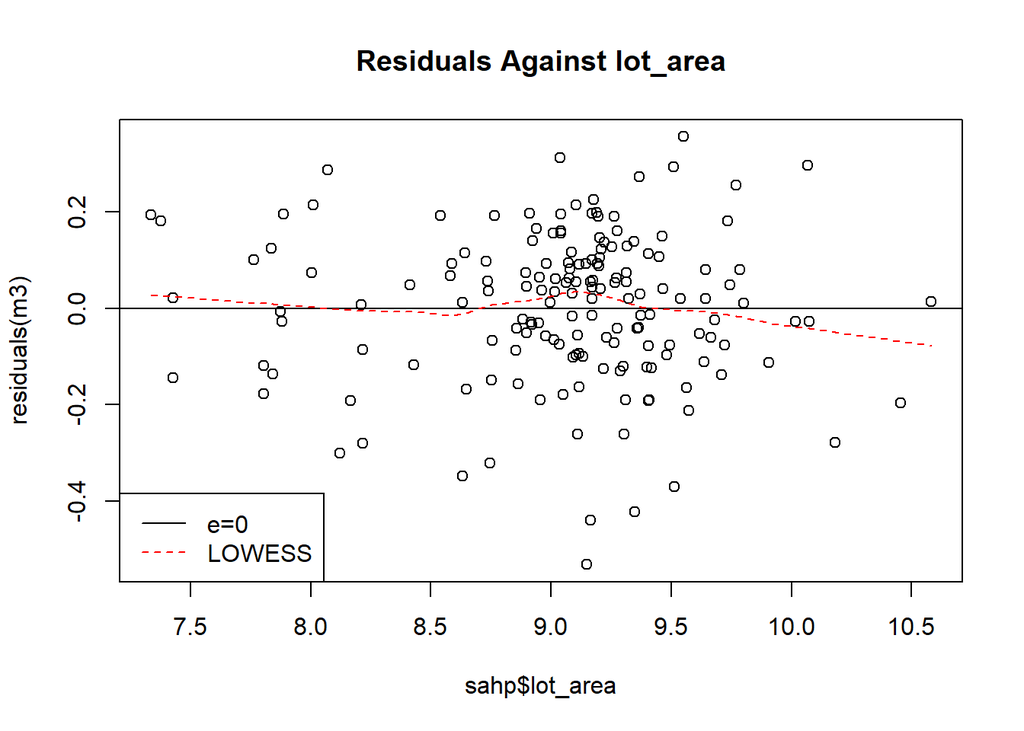

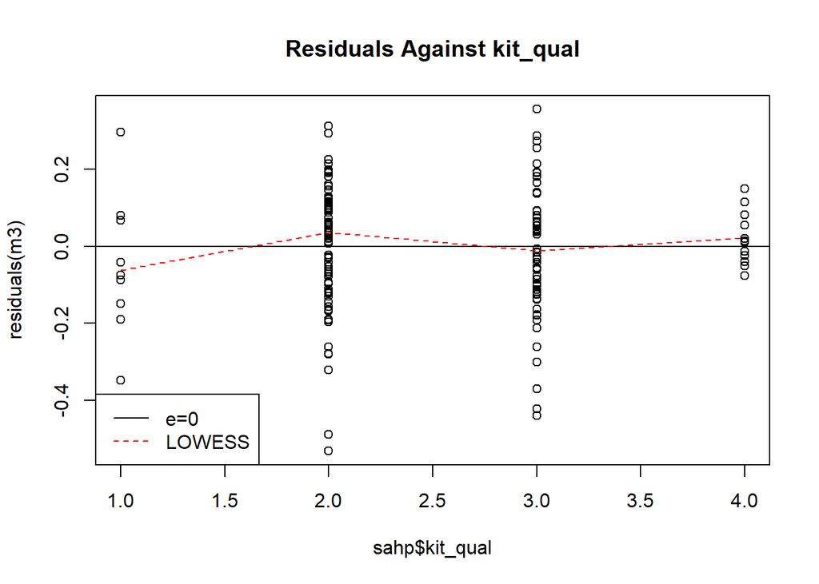

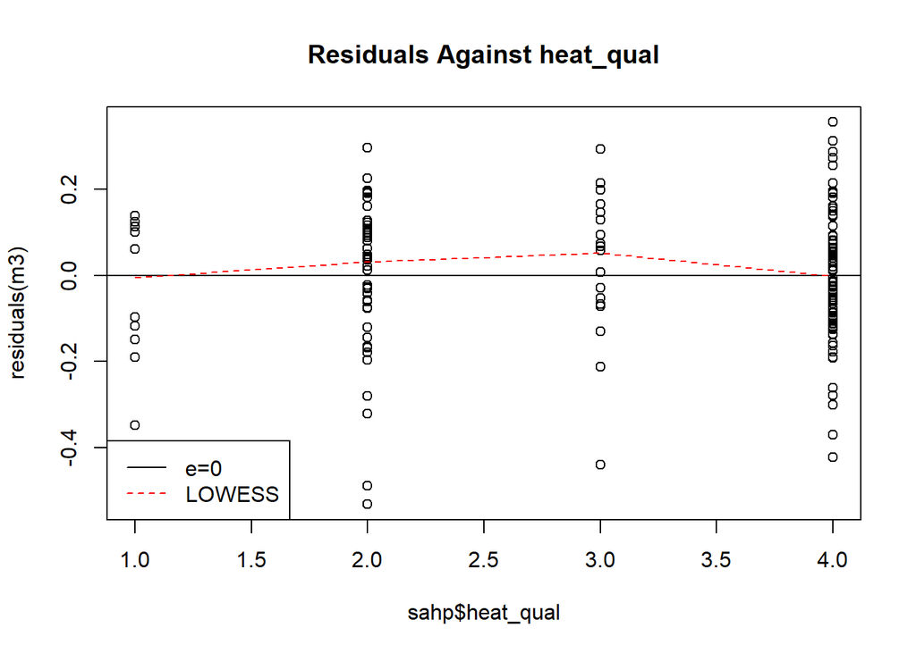

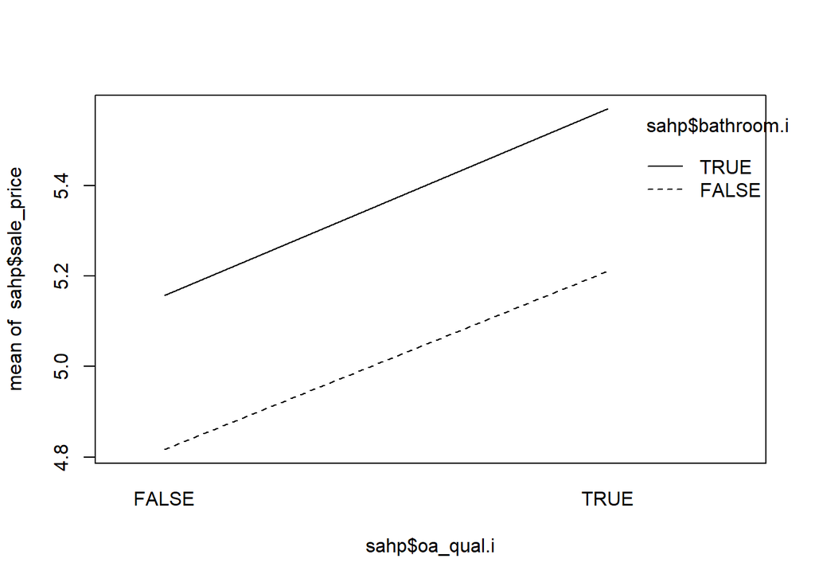

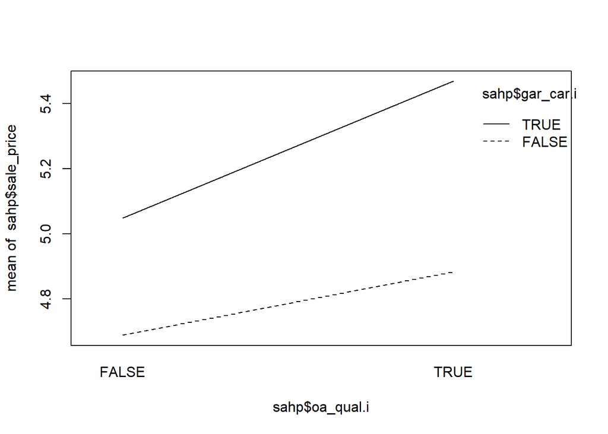

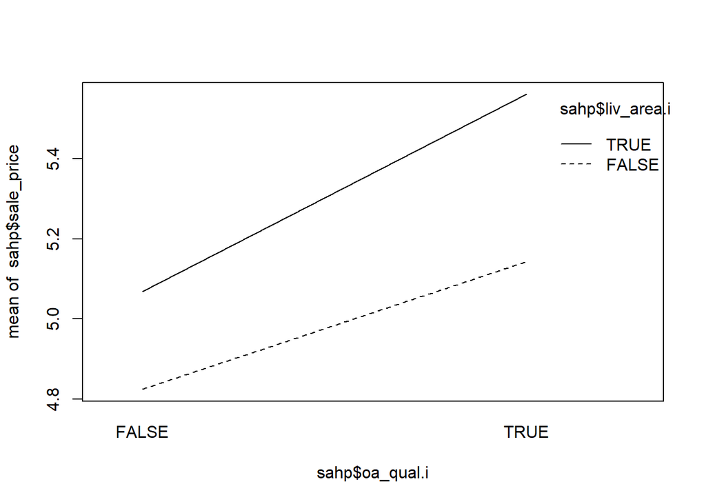

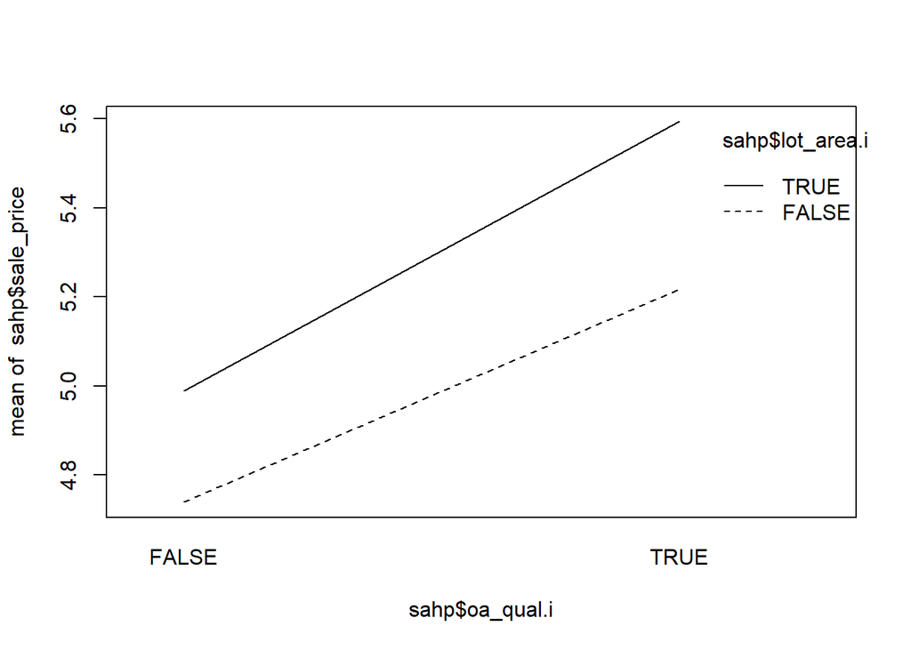

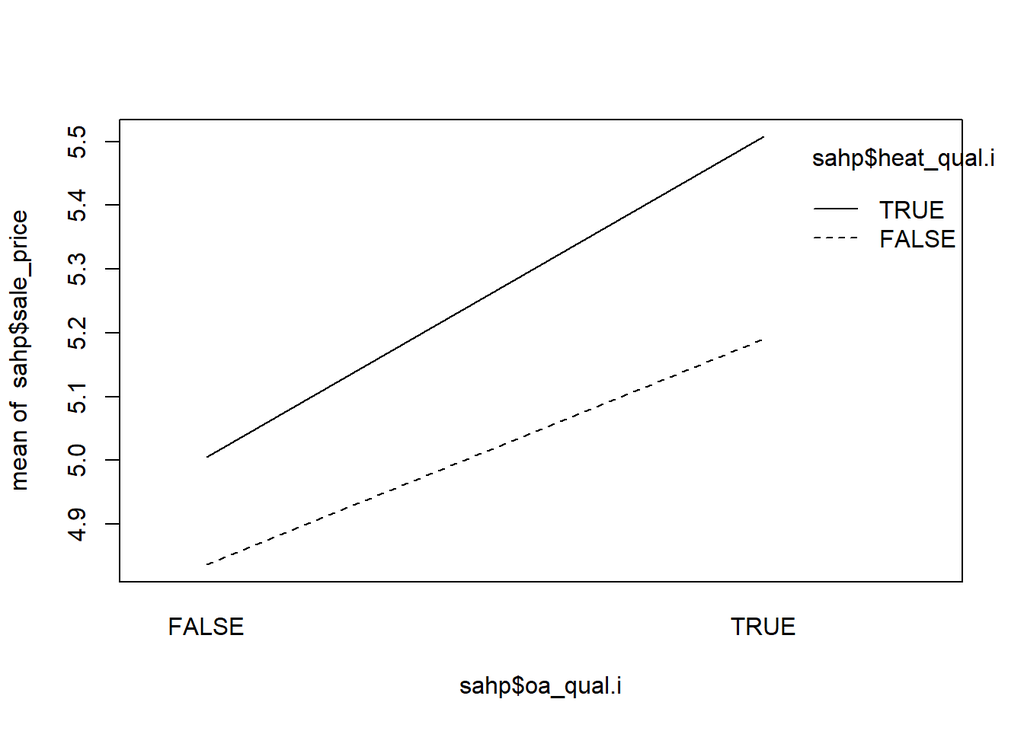

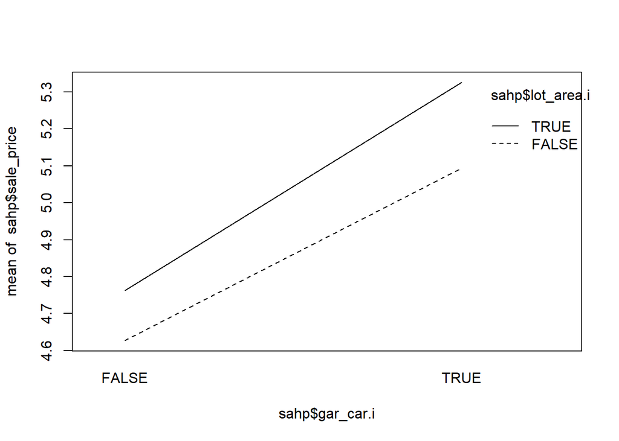

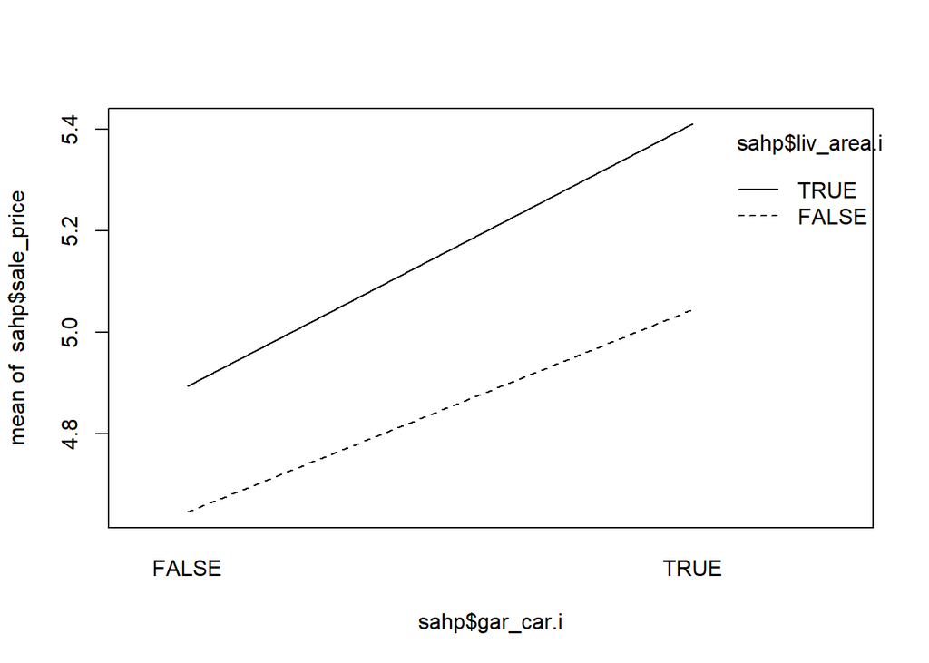

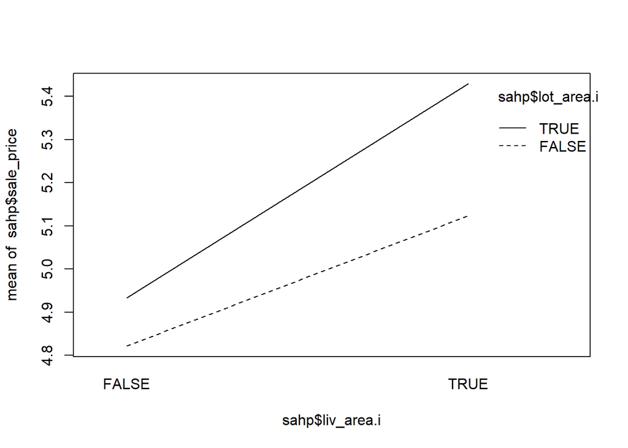

### 2. **Investigating Outliers and Influential Points**

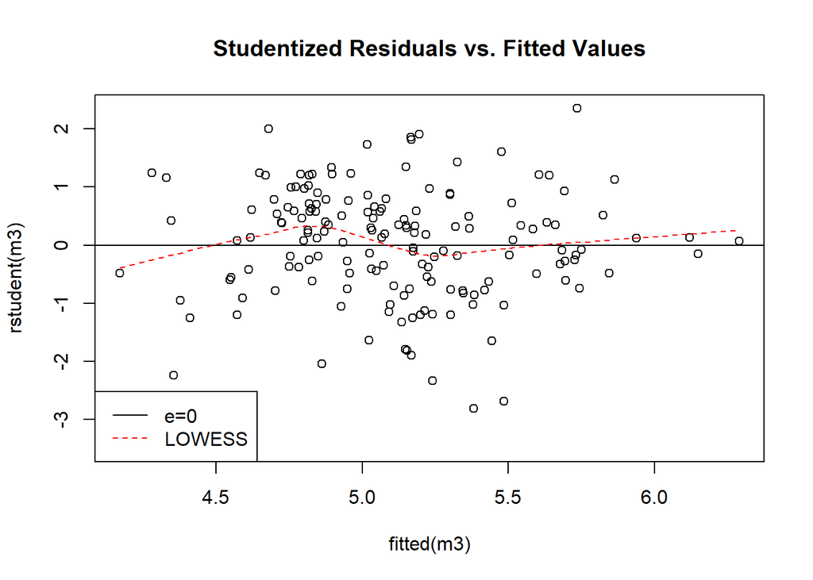

```
## integer(0)
```

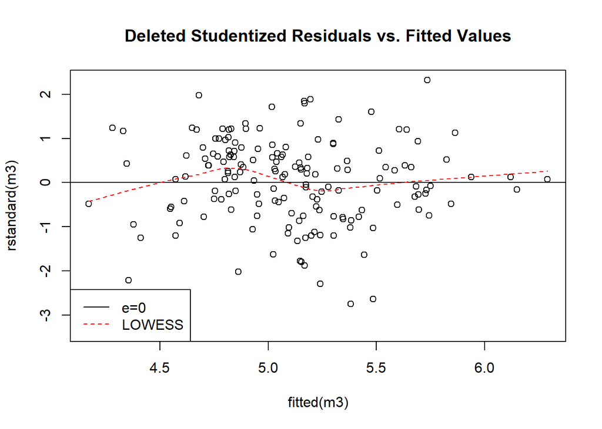

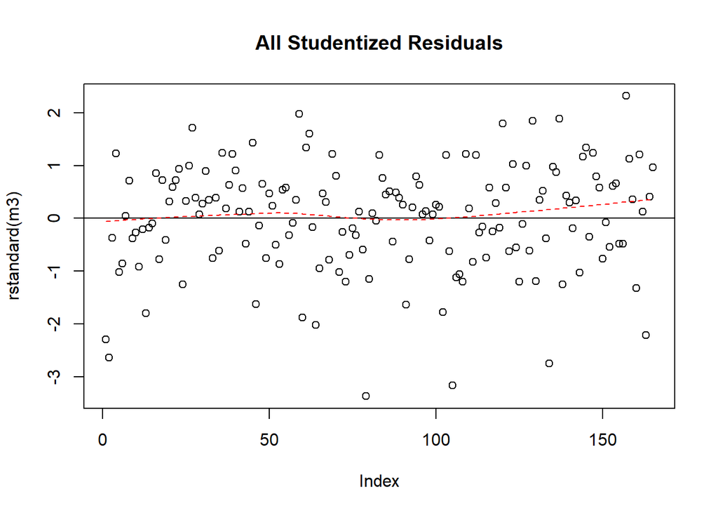

```
##  79 105
##  79 105
```

Another way of identifying outlying cases with respect to the X and Y is the hat matrix. The hat matrix, denoted by $H$, maps the observed values of the dependent variable to the predicted values and is defined as:

$$H = X(X^TX)^{-1}X^T$$

where:

$X$ is the design matrix of the model, containing the values of the predictor variables. $X^T$ is the transpose of the design matrix. $(X^TX)^{-1}$ is the inverse of the product of the transpose of $X$ and $X$. The diagonal elements of the hat matrix are often denoted as $H_{ii}$, representing the leverage values.if $H_{ii}$ is greater than 2p/n where p: number of parameters and n: sample size, then it is a high leverage point that potentially influences the model fit (Kutner and Nachtsheim 2014). The following cases were identified as outlying with regard to their X values:

```
##  17  51  52  81 105 115 138 143 157
##  17  51  52  81 105 115 138 143 157
```

The influence of the outlying cases on the fitted values and estimated regression coefficients will be measured below by investigating the DFFITS, Cook’s distance, and DFBETAS measures. DFFITS “Difference in Fits” is a measure that considers the influence of the ith case on the fitted value $\hat{Y}_i$ for this case. The DFFITS for the $i$-th observation is given by:

$$DFFITS_i = \frac{\hat{Y}_i -
\hat{Y}_{i(-i)}}{\sqrt{\text{MSE}_i \cdot h_{ii}}}$$

where: $\hat{Y}_i$ is the predicted value when the $i$-th observation is included in the model. $\hat{Y}_{i(-i)}$ is the predicted value when the $i$-th observation is excluded from the model. $\text{MSE}_i$ is the Mean Squared Error associated with the $i$-th observation. $h_{ii}$ is the leverage of the $i$-th observation. The rule of thumb for identifying influential cases: “a case is influential if the absolute value of DFFITS exceeds 1 for small to medium data sets and 2*sqrt(p/n) for large data sets” (Kutner and Nachtsheim 2014). The following cases were identified as influential:

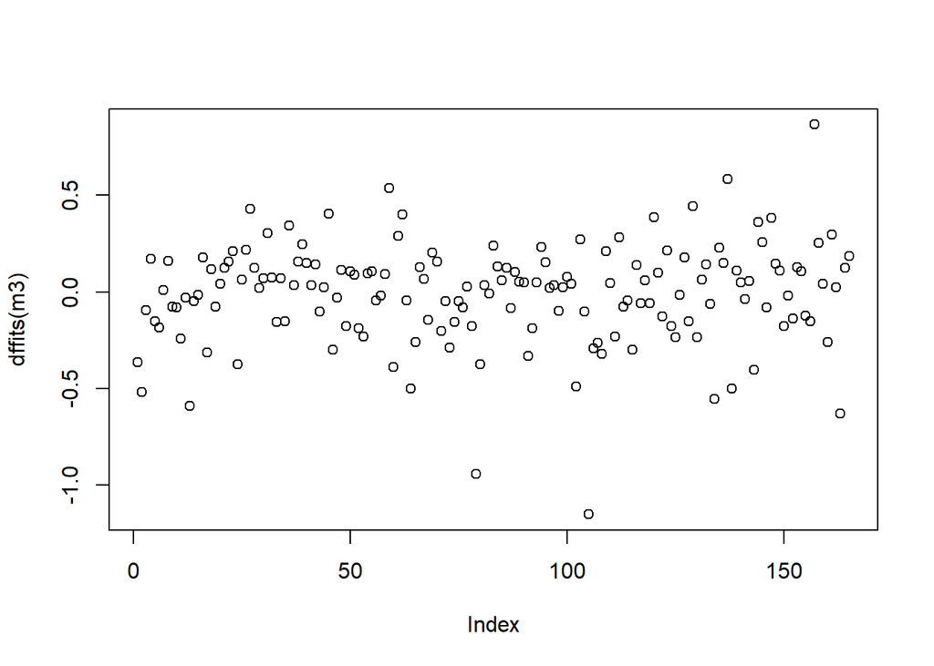

```
##   2  13  59  64  79 102 105 134 137 138 157 163
##   2  13  59  64  79 102 105 134 137 138 157 163
```

`DFBETAS` measures the standardized effect of deleting each individual observation on each coefficient.. For the $k$-th coefficient, `DFBETAS` is calculated as:

$$\text{dfbetas}_{ik} = \frac{b_k -
b_{k(i)}}{\sqrt{\text{MSE}_i^{(Ckk)}}}$$

where: - $b_k$ is the estimated coefficient for the $k$-th variable when all observations are included. - $b_{k(i)}$ is the estimated coefficient for the $k$-th variable when the $i$-th observation is excluded. - $\text{MSE}_i^{(Ckk)}$ is the Mean Squared Error associated with the $i$-th observation for the $k$-th coefficient.

The numerator represents the change in the estimated coefficient when the $i$-th observation is excluded, and the denominator is the square root of the Mean Squared Error for the $k$-th coefficient associated with the $i$-th observation. A good rule of thumb for identifying influential cases: “consider a case influential if the absolute value of DFBETAS exceeds 1 for small to medium data sets and 2/sqrt(n) for large data sets” (Kutner and Nachtsheim 2014) . The following orders of the DFBETAS exceed the threshold of 0.156:

```
##  [1]    1    2   24   36   61  120  144  147  229  244  280  303  343  390  394
## [16]  464  574  600  658  705  739  765  797  798  821  849  916  937  954  982
## [31] 1001 1050 1052 1095 1096 1127 1182 1257 1278 1285 1298 1318 1356 1379 1399
## [46] 1425 1483
```

```
## [1] 0.1556998
```

Some of the DFBETAS for the outlying cases 79 and 105 exceed the threshold of .156; the values are shown below:

```
##             dfbetas(m3)[79, ]
## (Intercept)       -0.04526719
## bedroom            0.21685602
## bathroom           0.04181523
## gar_car            0.37129838
## oa_qual            0.43155786
## liv_area          -0.08240367
## lot_area          -0.18490461
## kit_qual          -0.39760348
## heat_qual          0.23716358
```

```
##             dfbetas(m3)[105, ]
## (Intercept)        -0.58292899
## bedroom             0.11382003
## bathroom            0.02314357
## gar_car             0.54586741
## oa_qual             0.16359512
## liv_area           -0.64481393
## lot_area            0.54514367
## kit_qual            0.01876217
## heat_qual           0.19425173
```

Visualize the DFBETAS for each covariate :

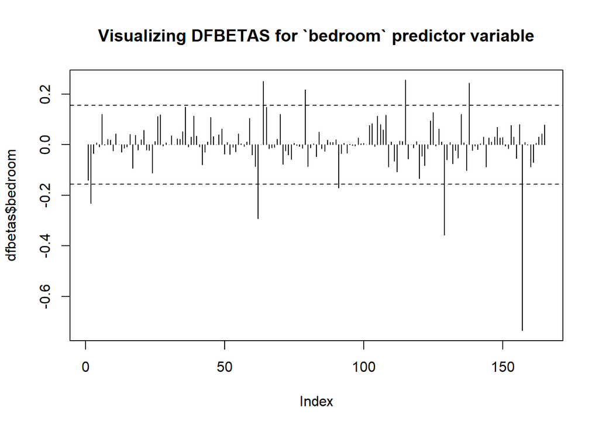

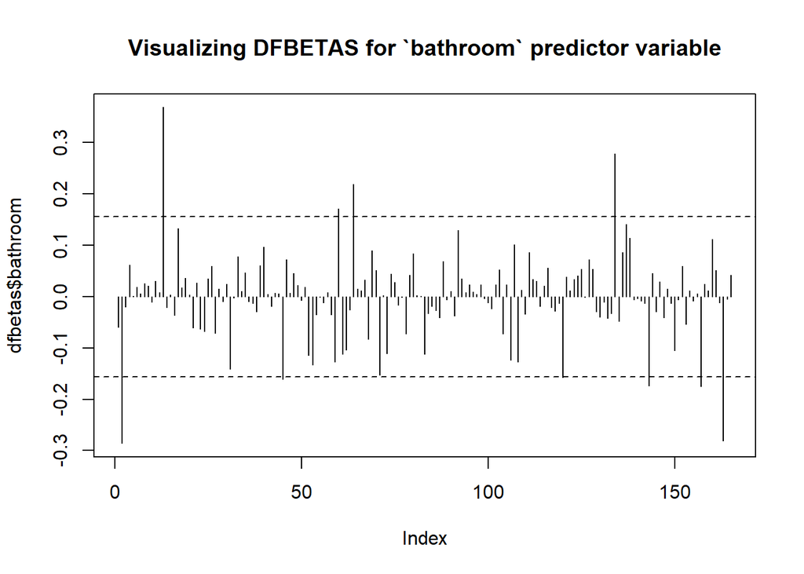

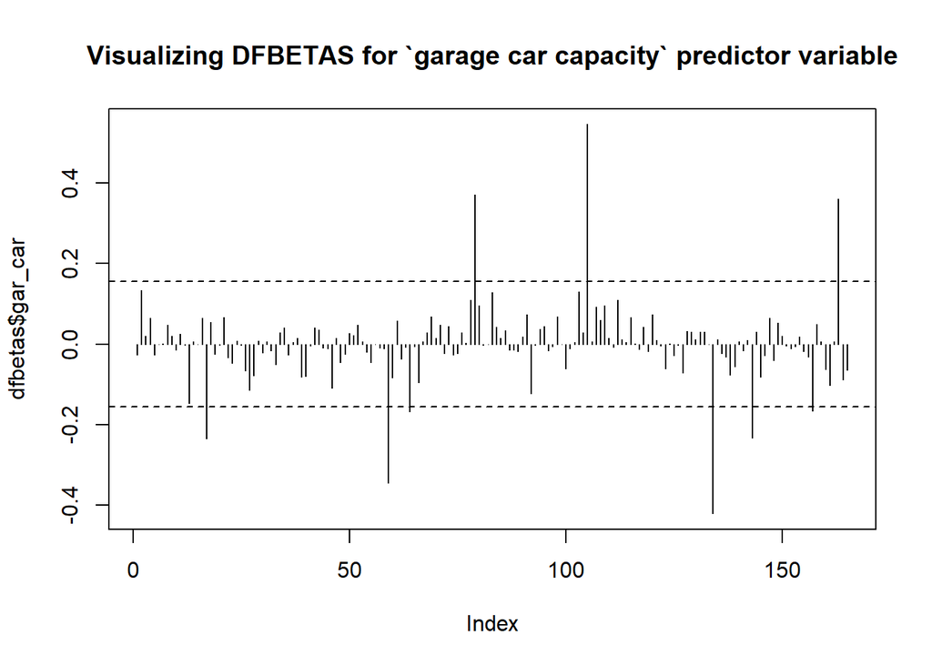

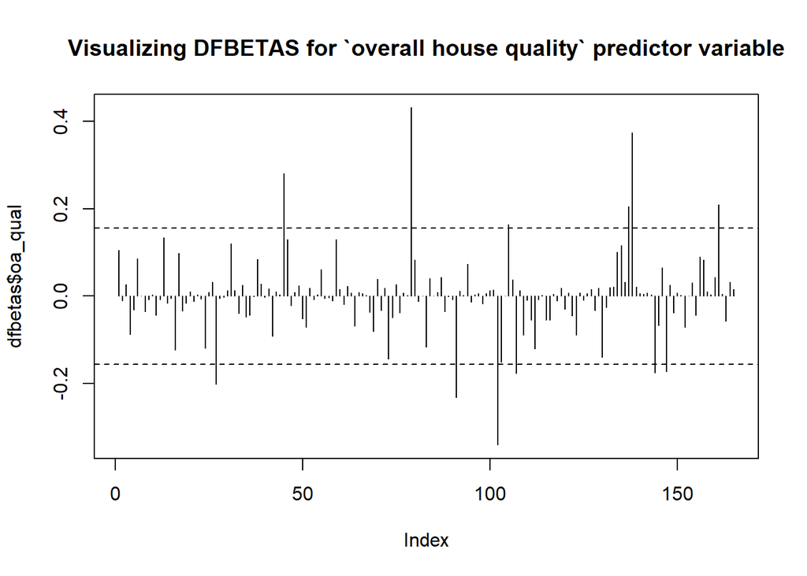

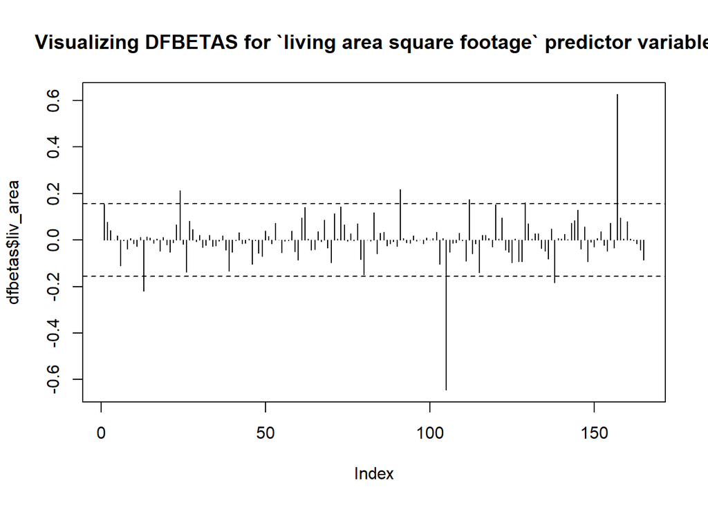

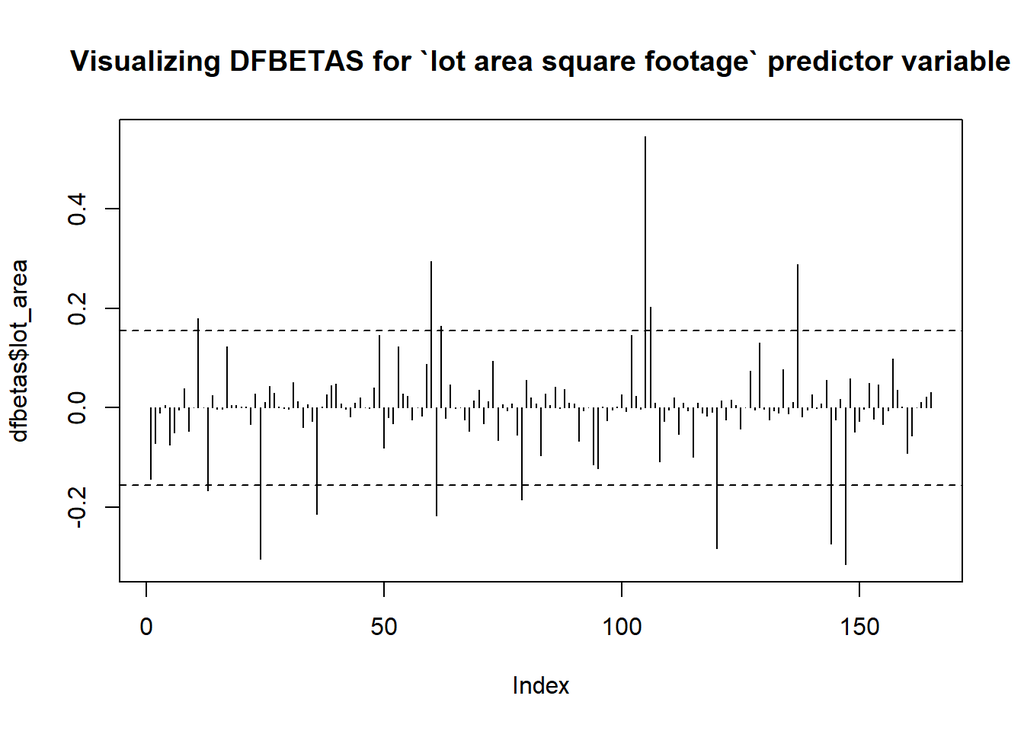

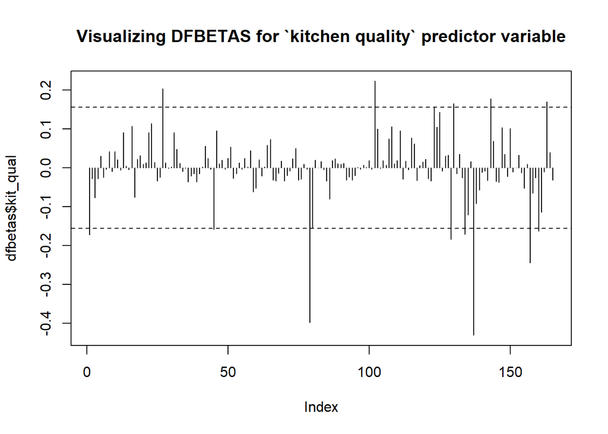

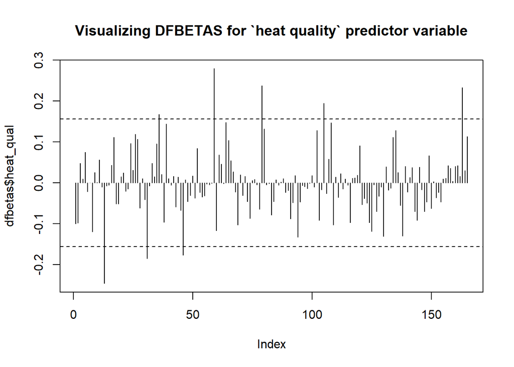

Finally, Cook’s distance measure considers the influence of the ith case on all n fitted values. Case 105 has a quantile that is higher than 10th percentile. Thus, case 105 might have apparent influence on the fitted values.

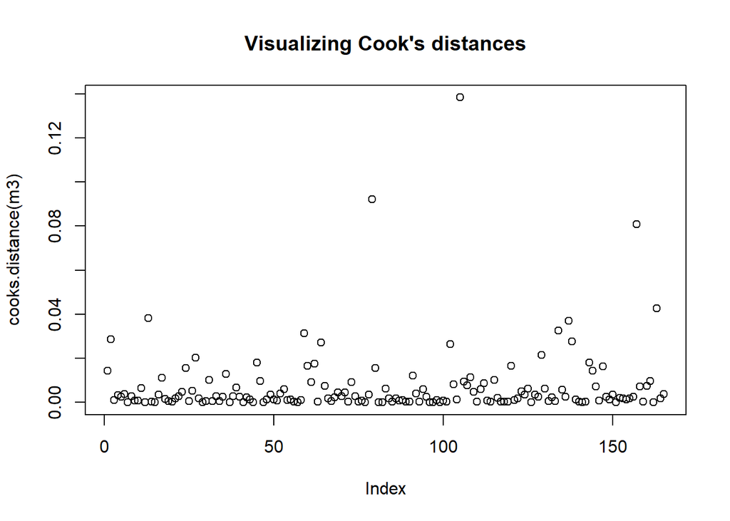

```
## 105
## 105
```

```
## named integer(0)
```

```
## Cook's distance for case 105 is: 0.1383999
```

Another ways of visualizing DFFITS, DFBETAS, and Cook’s Distances:

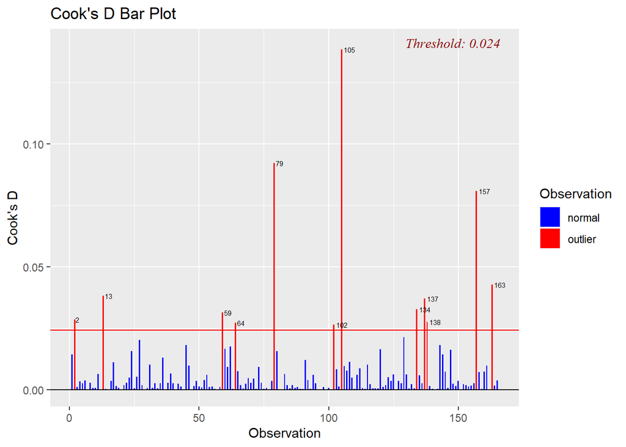

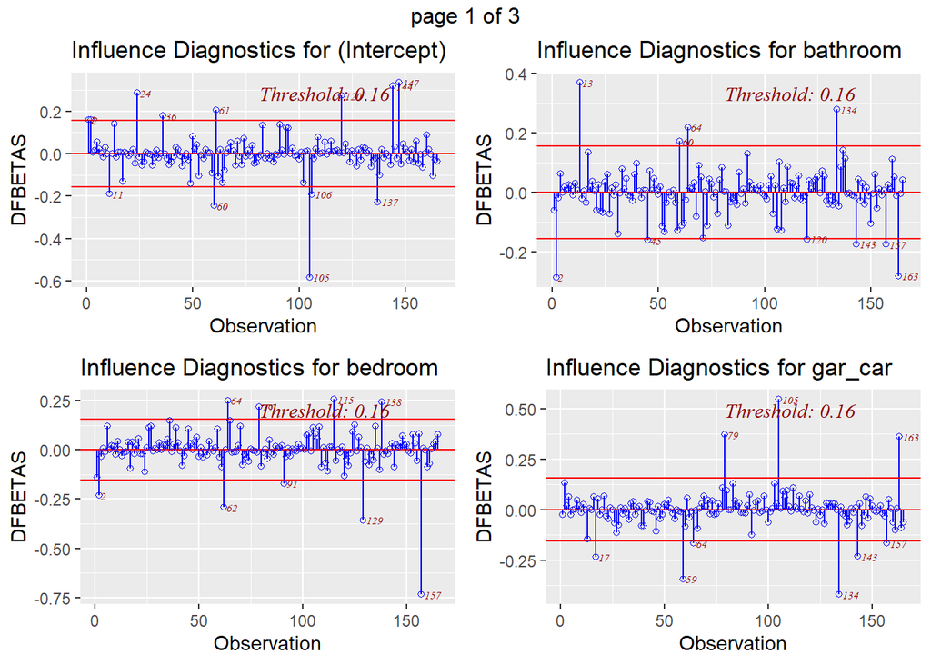

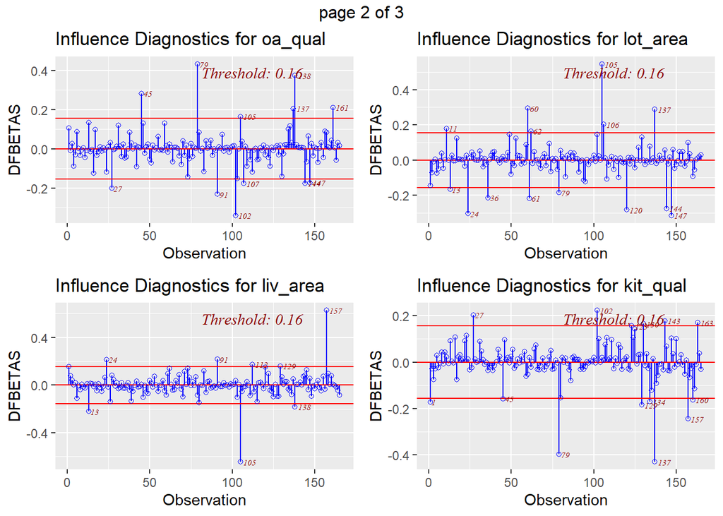

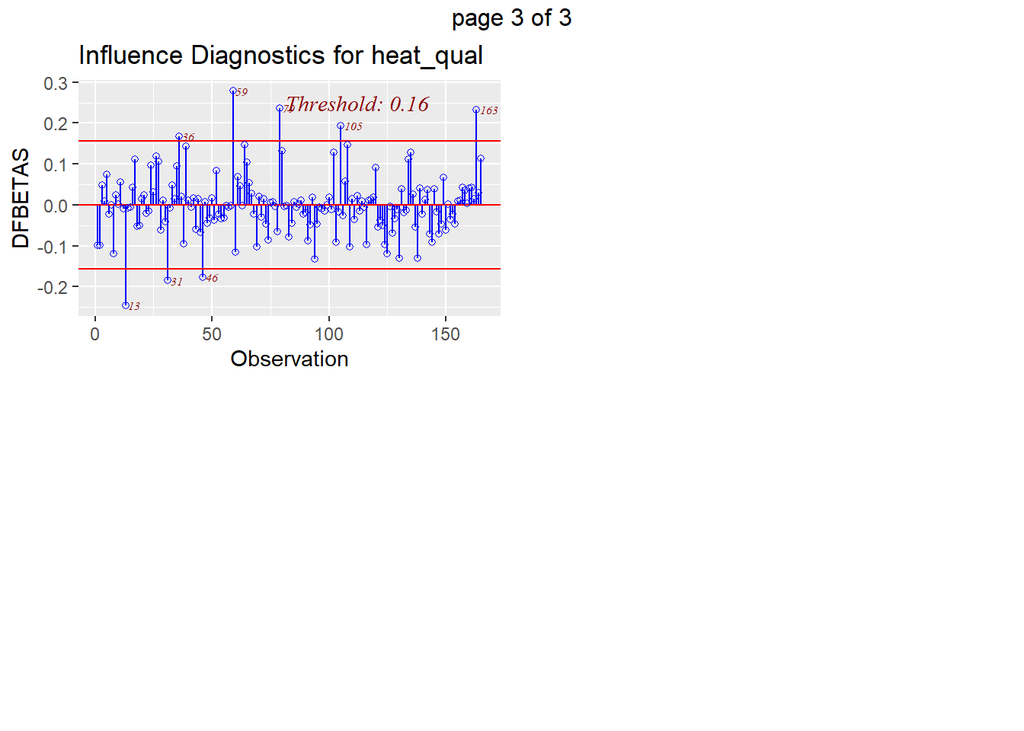

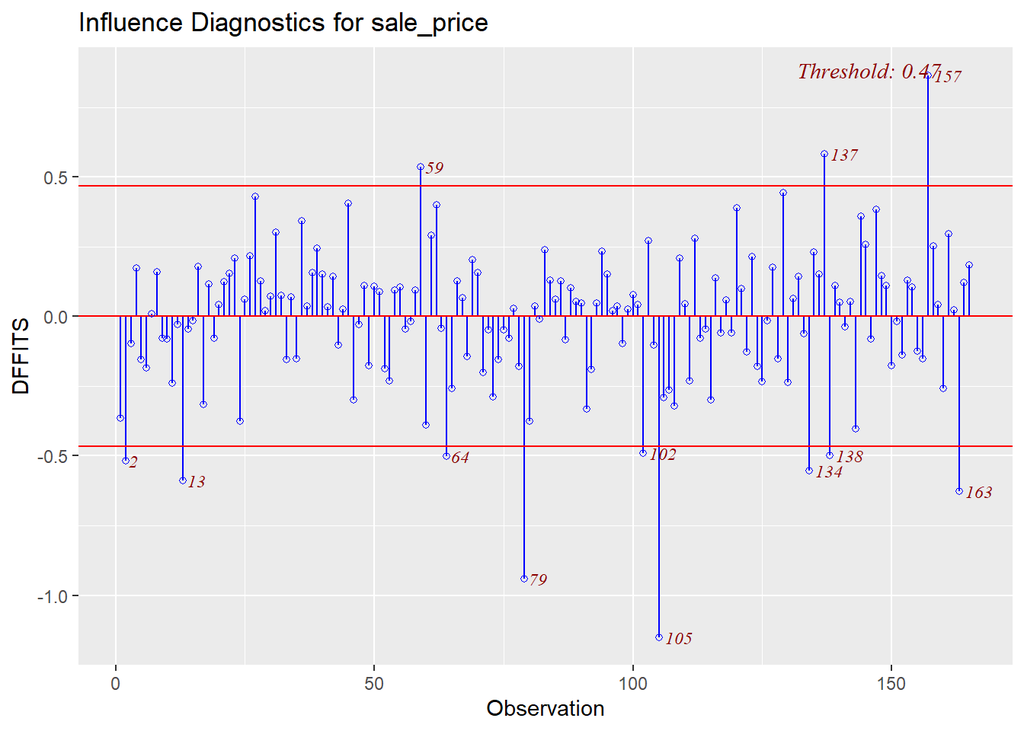

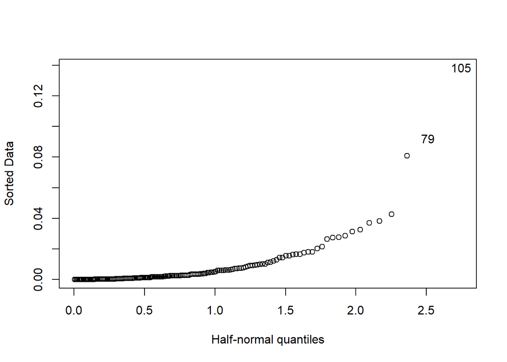

Model validation steps are repeated to compare a model with outliers to the one without outliers. As shown from the following two model validation steps, deleting the outliers (cases 79 and 105) improved the predictive performance of the regression model. The model without the outliers have lower MSPE value.

```
## Linear Regression
##
## 165 samples
##   8 predictor
##
## No pre-processing
## Resampling: Leave-One-Out Cross-Validation
## Summary of sample sizes: 164, 164, 164, 164, 164, 164, ...
## Resampling results:
##
##   RMSE       Rsquared   MAE
##   0.1687407  0.8405807  0.1320624
##
## Tuning parameter 'intercept' was held constant at a value of TRUE
```

```
## Linear Regression
##
## 163 samples
##   8 predictor
##
## No pre-processing
## Resampling: Leave-One-Out Cross-Validation
## Summary of sample sizes: 162, 162, 162, 162, 162, 162, ...
## Resampling results:
##
##   RMSE       Rsquared   MAE
##   0.1568723  0.8501684  0.1246642
##
## Tuning parameter 'intercept' was held constant at a value of TRUE
```

```
## Linear Regression
##
## 165 samples
##   8 predictor
##
## No pre-processing
## Resampling: Cross-Validated (10 fold)
## Summary of sample sizes: 149, 147, 148, 149, 148, 148, ...
## Resampling results:
##
##   RMSE      Rsquared   MAE
##   0.168878  0.8382907  0.1348459
##
## Tuning parameter 'intercept' was held constant at a value of TRUE
```

```
## Linear Regression
##
## 163 samples
##   8 predictor
##
## No pre-processing
## Resampling: Cross-Validated (10 fold)
## Summary of sample sizes: 146, 147, 146, 146, 147, 147, ...
## Resampling results:
##
##   RMSE       Rsquared   MAE
##   0.1524186  0.8684519  0.1229849
##
## Tuning parameter 'intercept' was held constant at a value of TRUE
```

Also, from the comparison of the two summary statistics tables below, it is shown that the standard error, which is a measure of the variability of the coefficient estimates that represents the average amount by which the estimate is expected to deviate from the true population parameter, is reduced for each coefficient estimate. The final model without the outliers is said to be the best multiple linear regression model.

```
##
## Call:
## lm(formula = sale_price ~ bedroom + bathroom + gar_car + oa_qual +
##     liv_area + lot_area + kit_qual + heat_qual, data = sahp)
##
## Residuals:
##      Min       1Q   Median       3Q      Max
## -0.53052 -0.09692  0.02033  0.10030  0.35485
##
## Coefficients:
##               Estimate Std. Error t value Pr(>|t|)
## (Intercept)  2.106e+00  2.268e-01   9.283  < 2e-16 ***
## bedroom     -3.681e-02  1.968e-02  -1.871 0.063219 .
## bathroom     5.142e-02  2.202e-02   2.336 0.020777 *
## gar_car      8.133e-02  2.251e-02   3.613 0.000407 ***
## oa_qual      1.396e-01  1.529e-02   9.131 3.34e-16 ***
## liv_area     1.794e-04  4.716e-05   3.805 0.000204 ***
## lot_area     1.647e-01  2.414e-02   6.820 1.89e-10 ***
## kit_qual     4.072e-02  2.785e-02   1.462 0.145787
## heat_qual    4.083e-02  1.485e-02   2.749 0.006674 **
## ---
## Signif. codes:  0 '***' 0.001 '**' 0.01 '*' 0.05 '.' 0.1 ' ' 1
##
## Residual standard error: 0.163 on 156 degrees of freedom
## Multiple R-squared:  0.8593, Adjusted R-squared:  0.852
## F-statistic: 119.1 on 8 and 156 DF,  p-value: < 2.2e-16
```

```
##
## Call:
## lm(formula = sale_price ~ bedroom + bathroom + gar_car + oa_qual +
##     liv_area + lot_area + kit_qual + heat_qual, data = sahp[-c(79,
##     105), ])
##
## Residuals:
##      Min       1Q   Median       3Q      Max
## -0.42585 -0.09906  0.01126  0.10552  0.33691
##
## Coefficients:
##               Estimate Std. Error t value Pr(>|t|)
## (Intercept)  2.249e+00  2.149e-01  10.467  < 2e-16 ***
## bedroom     -4.332e-02  1.839e-02  -2.355  0.01978 *
## bathroom     4.999e-02  2.053e-02   2.435  0.01602 *
## gar_car      6.065e-02  2.140e-02   2.834  0.00522 **
## oa_qual      1.305e-01  1.438e-02   9.074 5.11e-16 ***
## liv_area     2.139e-04  4.484e-05   4.770 4.24e-06 ***
## lot_area     1.559e-01  2.285e-02   6.823 1.92e-10 ***
## kit_qual     5.123e-02  2.614e-02   1.960  0.05179 .
## heat_qual    3.442e-02  1.390e-02   2.476  0.01438 *
## ---
## Signif. codes:  0 '***' 0.001 '**' 0.01 '*' 0.05 '.' 0.1 ' ' 1
##
## Residual standard error: 0.152 on 154 degrees of freedom
## Multiple R-squared:  0.8671, Adjusted R-squared:  0.8602
## F-statistic: 125.6 on 8 and 154 DF,  p-value: < 2.2e-16
```

### 3. Constant Variance

As shown from the plot below, there are no apparent issues with non-constant variance.

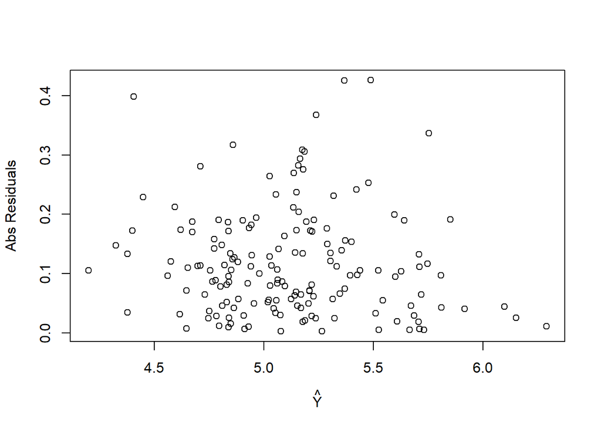

### 4. Normal Probability Plot

Also, the following normal quantile plot supports the normality of the final model’s residuals:

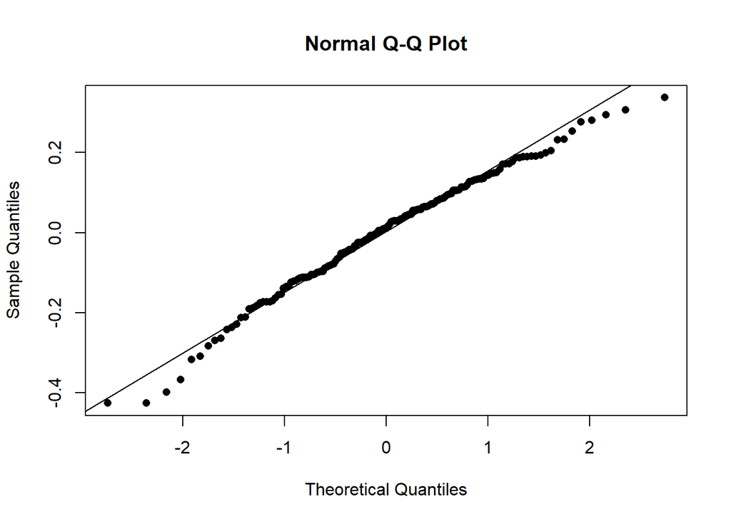

To answer the question of the analysis: which features of the house have the most significant influence on its sale price? The coefficient of multiple determination $R^2$ for each predictor variable is calculated as the ratio of the regression sum of squares (SSR) to the total sum of squares (SSTO) , and it is given by the formula:

$$R^2 = \frac{SSR}{SSTO}$$

where: $SSR$ is the regression sum of squares extracted from the Analysis of Variance (ANOVA) table below for each coefficient estimate, $SSTO$ is the total sum of squares that is calculated by adding the sum of squares for all coefficient estimates and sum of squares for the residuals shown in the ANOVA table below.

$R^2$ expresses the proportion of the total variance in the dependent variable that is explained by the independent variables in the model.

```
## Analysis of Variance Table
##
## Response: sale_price
##            Df  Sum Sq Mean Sq  F value    Pr(>F)
## bedroom     1  0.3348  0.3348  14.4942 0.0002025 ***
## bathroom    1 10.2020 10.2020 441.6338 < 2.2e-16 ***
## gar_car     1  3.9286  3.9286 170.0659 < 2.2e-16 ***
## oa_qual     1  5.8336  5.8336 252.5283 < 2.2e-16 ***
## liv_area    1  1.4385  1.4385  62.2697 5.196e-13 ***
## lot_area    1  1.1175  1.1175  48.3766 9.431e-11 ***
## kit_qual    1  0.2079  0.2079   8.9986 0.0031521 **
## heat_qual   1  0.1416  0.1416   6.1289 0.0143816 *
## Residuals 154  3.5575  0.0231
## ---
## Signif. codes:  0 '***' 0.001 '**' 0.01 '*' 0.05 '.' 0.1 ' ' 1
```

The table below shows the percentage of the explained variation in house sale price by each predictor variable:

| Predictor Variable | $R^2$ Value |
| --- | --- |
| Bedroom | 1.25% |
| Bathroom | 38.12% |
| Gar_car | 14.68% |
| Oa_qual | 21.80% |
| Liv_area | 5.38% |
| Lot_area | 4.18% |
| Kit_qual | 0.78% |
| Heat_qual | 0.53% |

# References

Chin, T. L., Chau, K. W. (2002). A Critical Review of Literature on The Hedonic Price Model. *International Journal for Housing Science and its Applications*, 27(2).

De Cock, D. (2011). Ames, Iowa: Alternative to the Boston Housing Data as an End of Semester Regression Project. *Journal of Statistics Education*, 19(3).

Feng, Y., Zhu, J. (2022). *R Programming: Zero to Pro*.

Feng, Y., Zhu, J. (2023). *r02pro: R Programming: Zero to Pro*. R package version 0.2, https://CRAN.R-project.org/package=r02pro.

Kutner, M. H., Nachtsheim, C. J., Neter, J., and Li, W. (2014), Applied Linear Statistical Models, 5th ed., McGraw-Hill Irwin.

Valchanov, I. (2021, October 20). *Exploring the 5 OLS Assumptions for Linear Regression Analysis*. 365 Data Science. https://365datascience.com/tutorials/statistics-tutorials/ols-assumptions/.

## R Codes

```r
# Load packages
library(tidyverse)
library(caret)
library(asbio)
library(olsrr)
library(xtable)
library(shiny)
library(knitr)
library(DT)
require(scatterplot3d)
require(Hmisc)
require(rgl)
require(faraway)
library(car)
library(vroom)
library(leaps)
library(corrplot)
library(ggplot2)
library(r02pro)
library(tibble)


#load data
data(sahp, package="r02pro") #sahp data set is a small version of the ames data set that is built under "modeldata" package, which originally contained 81 predictor variables and 2930 observations. sahp data set is under R package named "r02pro" that is built by Yang Feng and Jianan Zhu as a a companion package of the book "R Programming: Zero to Pro"


display_output <- function(dataset, out_type, filter_opt = 'none') {

  if (out_type == "html") {
    out_table <- DT::datatable(dataset, filter = filter_opt)
  } else {
    out_table <- knitr::kable(dataset)
  }

  out_table
}

# Function to calculate predicted sum of squares (PRESS)
PRESS <- function(linear.model) {
  #' calculate the predictive residuals
  pr <- residuals(linear.model)/(1-lm.influence(linear.model)$hat)
  #' calculate the PRESS
  PRESS <- sum(pr^2)

  return(PRESS)
}

head(sahp)
summary(sahp)

str(sahp)# we see that we have four variables of character type
# Select only character type variables
char_vars <- sahp %>%
  select(where(is.character))

#Extract relevant time components such as year, month, and day from the `dt_sold` variable. These components may be used as additional predictors in the model to capture seasonality or trends over different time scales.
sahp <- sahp %>%
  mutate(year_sold = year(dt_sold), mo_sold = month(dt_sold), day_sold = day(dt_sold))

#find unique levels of the character vectors and get their frequency tables
#for the house style
levels_house_style  <- unique(sahp$house_style)
table_house_style <- table(levels_house_style)

# Since 'house_style' is a nominal categorical variable, One-Hot encoding in R is used to convert the "house_style" column into binary dummy variables.  The -1 in the formula removes the intercept term
sahp <- within(sahp, {
  style <- model.matrix(~ house_style - 1)
})

#for the kitchen quality
levels_kitchen <- unique(sahp$kit_qual)
table_kitchen <- table(levels_kitchen)

#for the heat quality
levels_heat_quality <- unique(sahp$heat_qual)
table_heat_quality <- table(levels_heat_quality)

# Convert selected character variables to unordered factors
sahp <- sahp %>%
  mutate_at(vars(kit_qual, heat_qual), as.factor)

# Convert kitchen quality variable to ordered factor with specified levels
sahp$kit_qual <- factor(sahp$kit_qual, ordered = TRUE, levels = c("Fair", "Average", "Good", "Excellent"))

# Convert heat quality variable to ordered factor with specified levels
sahp$heat_qual <- factor(sahp$heat_qual, ordered = TRUE, levels = c("Fair", "Average", "Good", "Excellent"))


# Convert kitchen quality variable to numeric
sahp$kit_qual <- as.numeric(sahp$kit_qual)

# Convert heat quality variable to numeric
sahp$heat_qual <- as.numeric(sahp$heat_qual)

# Convert central air variable to binary (0, 1)
# Convert "Y" to 1, "N" to 0 using ifelse
sahp$central_air <- ifelse(sahp$central_air == "Y", 1, 0)

#the total number of NA values in the sahp data set
na_values <- sum(is.na(sahp))

# There are three NA values in the `sahp` data set : one house did not have sale price, another did not specify the overall quality of the house, and the third did not specify the size of garage in car capacity or if there is even a car garage. Since median imputation of NA values is robust to outliers, NA values are replaced with the median of the column the NA value in.
sahp$sale_price[is.na(sahp$sale_price)] <- median(sahp$sale_price, na.rm = TRUE)
sahp$oa_qual[is.na(sahp$oa_qual)] <- median(sahp$oa_qual, na.rm = TRUE)
sahp$gar_car[is.na(sahp$gar_car)] <- median(sahp$gar_car, na.rm = TRUE)

# Create a probability density plot of the sale_price using ggplot2
ggplot(data.frame(x = sahp$sale_price), aes(x)) +
  geom_density(fill = "blue", color = "black", alpha = 0.5) +
  labs(title = "Probability Density Plot", x = "sale_price")


sahp$sale_price <- log(sahp$sale_price)

# Create a probability density plot of the sale_price after log transformation using ggplot2
ggplot(data.frame(x = sahp$sale_price), aes(x)) +
  geom_density(fill = "blue", color = "black", alpha = 0.5) +
  labs(title = "Probability Density Plot", x = "sale_price")

m <- lm(sale_price ~ bedroom+ bathroom+ gar_car+ oa_qual+ liv_area+ lot_area+ kit_qual+ heat_qual+ central_air+ year_sold+ mo_sold+ day_sold+ style[, "house_style1.5Fin"] + style[, "house_style1Story"] +style[, "house_style2Story"]+ style [, "house_styleSFoyer"]+ style[, "house_styleSLvl"],  data = sahp)

summary(m) # from the summary table, "house_styleSLvl" is most likely perfectly multicollinear with other predictor variables, so it is dropped from the model.

m1 <- lm(sale_price ~ bedroom+ bathroom+ gar_car+ oa_qual+ liv_area+ lot_area+ kit_qual+ heat_qual+ central_air+ year_sold+ mo_sold+ day_sold+ style[, "house_style1.5Fin"] + style[, "house_style1Story"] +style[, "house_style2Story"]+ style [, "house_styleSFoyer"],  data = sahp)

summary(m1)

columns_to_exclude <- c("dt_sold", "house_style")
sahp <- sahp[, !names(sahp) %in% columns_to_exclude]

# Create scatterplot matrix

pairs(sahp[, 1:4])
pairs(sahp[, 5:8])
pairs(sahp[, 9:13])


# Calculate the correlation matrix of the variables
as.data.frame(cor(sahp) )



for (i in 1:6){
  par(mfrow=c(1,2))
  stripchart(sahp[,i], main = names(sahp)[i],
                          vertical = T, method = "jitter")
  boxplot(sahp[,i], main = names(sahp)[i])
  par(mfrow=c(1,1))
}

for (i in 10:13){
  par(mfrow=c(1,2))
  stripchart(sahp[,i], main = names(sahp)[i],
                          vertical = T, method = "jitter")
  boxplot(sahp[,i], main = names(sahp)[i])
  par(mfrow=c(1,1))
}

# Create a probability density plot of the lot_area after log transformation using ggplot2
ggplot(data.frame(x = sahp$lot_area), aes(x)) +
  geom_density(fill = "blue", color = "black", alpha = 0.5) +
  labs(title = "Probability Density Plot", x = "lot_area")
```

```r
sahp$lot_area <- log(sahp$lot_area)

# Create a probability density plot of the lot_area after log transformation using ggplot2
ggplot(data.frame(x = sahp$lot_area), aes(x)) +
  geom_density(fill = "blue", color = "black", alpha = 0.5) +
  labs(title = "Probability Density Plot", x = "lot_area")


#Added variable plots
m1 <- lm(sale_price ~ bedroom+ bathroom+ gar_car+ oa_qual+ liv_area+ lot_area+ kit_qual+ heat_qual+ central_air+ year_sold+ mo_sold+ day_sold+ style[, "house_style1.5Fin"] + style[, "house_style1Story"] +style[, "house_style2Story"]+ style [, "house_styleSFoyer"],  data = sahp)
prplot(m1,1)
title("Added Variable Plot for the Bedroom Covariate")

prplot(m1,2)
title("Added Variable Plot for the Bathroom Covariate")


prplot(m1,3)
title("Added Variable Plot for the gar_car Covariate")


prplot(m1,4)
title("Added Variable Plot for the oa_qual Covariate")


prplot(m1,5)
title("Added Variable Plot for the liv_area Covariate")


prplot(m1,6)
title("Added Variable Plot for the lot_area Covariate")


prplot(m1,7)
title("Added Variable Plot for the kit_qual Covariate")


prplot(m1,8)
title("Added Variable Plot for the heat_qual Covariate")


prplot(m1,9)
title("Added Variable Plot for the cental_air Covariate")


prplot(m1,10)
title("Added Variable Plot for the year_sold Covariate")


prplot(m1,11)
title("Added Variable Plot for the mo_sold Covariate")


prplot(m1,12)
title("Added Variable Plot for the day_sold Covariate")


prplot(m1,13)
title("Added Variable Plot for the house_style1.5Fin Covariate")


prplot(m1,14)
title("Added Variable Plot for the house_style1Story Covariate")


prplot(m1,15)
title("Added Variable Plot for the house_style2Story Covariate")


prplot(m1,16)
title("Added Variable Plot for the house_styleSFoyer Covariate")


as.data.frame(vif(m1))

m2 <- lm(sale_price ~ bedroom+ bathroom+ gar_car+ oa_qual+ liv_area+ lot_area+ kit_qual+ heat_qual+ central_air+ year_sold+ mo_sold+ day_sold+ style[, "house_style1.5Fin"] + style [, "house_styleSFoyer"],  data = sahp)

as.data.frame(vif(m2))


ma <- regsubsets(sale_price ~ bedroom+ bathroom+ gar_car+ oa_qual+ liv_area+ lot_area+ kit_qual+ heat_qual+ central_air+ year_sold+ mo_sold+ day_sold+ style[, "house_style1.5Fin"] + style [, "house_styleSFoyer"],  data = sahp, method = "seqrep")
(sma <- summary(ma))

sma$adjr2 #biggest value is better predicting model


plot(2:9,sma$adjr2, xlab = "Number of Parameters", ylab = expression(R^2[adj]))

sma$bic


plot(2:9, sma$bic, xlab = "Number of Parameters", ylab = expression(BIC))


sma$cp


plot(2:9, sma$cp, xlab = "Number of Parameters", ylab = expression(C[p]))

# first best subset model
m3 <- lm(sale_price ~ bedroom+ bathroom+ gar_car+ oa_qual+ liv_area+ lot_area+ kit_qual+ heat_qual,  data = sahp)

# second best subset model
m4 <- lm(sale_price ~ bedroom+ bathroom+ gar_car+ oa_qual+ liv_area+ lot_area+ kit_qual,  data = sahp)

# Extract AIC
cat("The AIC for the reduced model with 9 parameters is:", extractAIC(m3),"where 9 is the number of parameters (all predictor variables + the intercept) and -589.8394 is the AIC value", "\n")

cat("The AIC for the full model with 8 parameters is:", extractAIC(m4),"where 8 is the number of parameters (all predictor variables + the intercept) and -584.0313 is the AIC value", "\n")



# Extract PRESS (Predicted Error Sum of Squares, it is a validation statistic for measuring the predictive performance of the model, we need smallest value of deleted residuals)

PRESS(m3) #has the smallest PRESS value
PRESS(m4)


m3 <- lm(sale_price ~ bedroom+ bathroom+ gar_car+ oa_qual+ liv_area+ lot_area+ kit_qual+ heat_qual,  data = sahp)
m4 <- lm(sale_price ~ bedroom+ bathroom+ gar_car+ oa_qual+ liv_area+ lot_area+ kit_qual,  data = sahp)


# Define the training method
tr <- trainControl(method="LOOCV")

# Train the first best subset model (m3)
mreduced.1 <- train(sale_price ~ bedroom+ bathroom+ gar_car+ oa_qual+ liv_area+ lot_area+ kit_qual+ heat_qual, data=sahp, method = "lm", trControl = tr)
print(mreduced.1)

# Train the first best subset model (m4)
mreduced.2 <- train(sale_price ~ bedroom+ bathroom+ gar_car+ oa_qual+ liv_area+ lot_area+ kit_qual, data=sahp, method = "lm", trControl = tr)
print(mreduced.2)


# Define the training method
set.seed(123)
tr <- trainControl(method = "cv", number = 10)

# Train the first best subset model (m3)
mreduced.1 <- train(sale_price ~ bedroom+ bathroom+ gar_car+ oa_qual+ liv_area+ lot_area+ kit_qual+ heat_qual, data=sahp, method = "lm", trControl = tr)
print(mreduced.1)

# Train the first best subset model (m4)
mreduced.2 <- train(sale_price ~ bedroom+ bathroom+ gar_car+ oa_qual+ liv_area+ lot_area+ kit_qual, data=sahp, method = "lm", trControl = tr)
print(mreduced.2)

# Histogram of residuals: checks for normality
hist(m3$residuals, col = "lightblue", main = "Histogram of Residuals") #this supports normality

#Residuals' Probability Density Plot, looks close to a normal distribution
ggplot(data.frame(x = residuals(m3)), aes(x)) +
  geom_density(fill = "blue", color = "black", alpha = 0.5) +
  labs(title = "Residuals' Probability Density Plot", x = "residuals(m3)")

# Model looks appropriate
plot(fitted(m3), residuals(m3), main = "Fitted Vs. Residuals Plot",
     xlab = "Fitted Values", ylab = "Residuals")


# Plot residuals against sale_price
plot(sahp$sale_price, residuals(m3), main = "Residuals Against sale_price")
abline(h = 0)
lines(lowess(sahp$sale_price, residuals(m3)), lty = 2, col = "red")
legend("bottomleft", c("e=0", "LOWESS"), col = c("black", "red"), lty = c(1, 2))

# Plot residuals against bedroom
plot(sahp$bedroom, residuals(m3), main = "Residuals Against bedroom")
abline(h = 0)
lines(lowess(sahp$bedroom, residuals(m3)), lty = 2, col = "red")
legend("bottomleft", c("e=0", "LOWESS"), col = c("black", "red"), lty = c(1, 2))

# Plot residuals against bathroom
plot(sahp$bathroom, residuals(m3), main = "Residuals Against bathroom")
abline(h = 0)
lines(lowess(sahp$bathroom, residuals(m3)), lty = 2, col = "red")
legend("bottomleft", c("e=0", "LOWESS"), col = c("black", "red"), lty = c(1, 2))
```

```r
# Plot residuals against gar_car
plot(sahp$gar_car, residuals(m3), main = "Residuals Against gar_car")
abline(h = 0)
lines(lowess(sahp$gar_car, residuals(m3)), lty = 2, col = "red")
legend("bottomleft", c("e=0", "LOWESS"), col = c("black", "red"), lty = c(1, 2))

# Plot residuals against oa_qual
plot(sahp$oa_qual, residuals(m3), main = "Residuals Against oa_qual")
abline(h = 0)
lines(lowess(sahp$oa_qual, residuals(m3)), lty = 2, col = "red")
legend("bottomleft", c("e=0", "LOWESS"), col = c("black", "red"), lty = c(1, 2))

# Plot residuals against liv_area
plot(sahp$liv_area, residuals(m3), main = "Residuals Against liv_area")
abline(h = 0)
lines(lowess(sahp$liv_area, residuals(m3)), lty = 2, col = "red")
legend("bottomleft", c("e=0", "LOWESS"), col = c("black", "red"), lty = c(1, 2))

# Plot residuals against lot_area
plot(sahp$lot_area, residuals(m3), main = "Residuals Against lot_area")
abline(h = 0)
lines(lowess(sahp$lot_area, residuals(m3)), lty = 2, col = "red")
legend("bottomleft", c("e=0", "LOWESS"), col = c("black", "red"), lty = c(1, 2))

# Plot residuals against kit_qual
plot(sahp$kit_qual, residuals(m3), main = "Residuals Against kit_qual")
abline(h = 0)
lines(lowess(sahp$kit_qual, residuals(m3)), lty = 2, col = "red")
legend("bottomleft", c("e=0", "LOWESS"), col = c("black", "red"), lty = c(1, 2))

# Plot residuals against heat_qual
plot(sahp$heat_qual, residuals(m3), main = "Residuals Against heat_qual")
abline(h = 0)
lines(lowess(sahp$heat_qual, residuals(m3)), lty = 2, col = "red")
legend("bottomleft", c("e=0", "LOWESS"), col = c("black", "red"), lty = c(1, 2))

sahp$bathroom.i <- sahp$bathroom > mean(sahp$bathroom)

sahp$gar_car.i <- sahp$gar_car > mean(sahp$gar_car)

sahp$oa_qual.i <- sahp$oa_qual > mean(sahp$oa_qual)

sahp$liv_area.i <- sahp$liv_area > mean(sahp$liv_area)

sahp$lot_area.i <- log(sahp$lot_area) > mean(log(sahp$lot_area))

sahp$heat_qual.i <- sahp$heat_qual > mean(sahp$heat_qual)

sahp$central_air.i <- sahp$central_air > mean(sahp$central_air)

print(sahp)

interaction.plot(sahp$oa_qual.i,sahp$bathroom.i,sahp$sale_price )

interaction.plot(sahp$oa_qual.i,sahp$gar_car.i,sahp$sale_price )

interaction.plot(sahp$oa_qual.i,sahp$liv_area.i,sahp$sale_price )

interaction.plot(sahp$oa_qual.i,sahp$lot_area.i,sahp$sale_price )

interaction.plot(sahp$oa_qual.i,sahp$heat_qual.i,sahp$sale_price )


#testing more interaction plots out of curiosity (if any would improve the predictive measures of the regression model)
interaction.plot(sahp$gar_car.i,sahp$lot_area.i,sahp$sale_price )

interaction.plot(sahp$gar_car.i,sahp$liv_area.i,sahp$sale_price )

interaction.plot(sahp$liv_area.i,sahp$lot_area.i,sahp$sale_price )

# Plot studentized residuals against fitted values
plot(rstudent(m3) ~ fitted(m3), main = "Studentized Residuals vs. Fitted Values")
abline(h = 0)
lines(lowess(fitted(m3), rstudent(m3)), lty = 2, col = "red")
legend("bottomleft", c("e=0", "LOWESS"), col = c("black", "red"), lty = c(1, 2))

# Identify studentized residuals
identify(rstudent(m3) ~ fitted(m3))

# Plot deleted studentized residuals against fitted values
plot(rstandard(m3) ~ fitted(m3), main = "Deleted Studentized Residuals vs. Fitted Values")
abline(h = 0)
lines(lowess(fitted(m3), rstandard(m3)), lty = 2, col = "red")
legend("bottomleft", c("e=0", "LOWESS"), col = c("black", "red"), lty = c(1, 2))

# Plot all deleted studentized residuals
plot(rstandard(m3), main = "All Studentized Residuals")
abline(h = 0)
lines(lowess(rstandard(m3)), lty = 2, col = "red")

# Identify observations with absolute deleted studentized residuals greater than 3
which(abs(rstandard(m3)) > 3)  # Two unusual residuals


#The hat matrix is also useful after the model has been selected and fitted for determining whether an inference for a mean response or a new observation involves a substantial extrapolation beyond the range of the data.

#If h_new,new is well within the range of leverage values hii for the cases in the data set, no extrapolation is involved. On the other hand, if h_new,new is much larger than the leverage values for the cases in the data set, an extrapolation is indicated.

#hat values are the diagonal elements of the hat matrix
#if hii is greater than 2p/n, then it is a high leverage point (potentially influence the model fit)
which(hatvalues(m3)> 2*9/165) # High leverage? indicate outlying cases with regard to their X values.


 # DFFITS measure considers the influence of the ith case on the fitted value Y.hat for this case,
plot(dffits(m3)) # Compare to 2sqrt(p/n)
which(abs(dffits(m3))> 2*sqrt(9/165)) # a guideline for identifying influential cases: a case is influential if the absolute value of DFFITS exceeds 1 for small to medium data sets and 2*sqrt(p/n) for large data sets.

#dfbetas tell us the standardized effect of deleting each individual observation on each coefficient. The DFBETAS value by its sign indicates whether inclusion of a case leads to an increase or a decrease in the estimated regression coefficient, and its absolute magnitude shows the size of the difference relative to the estimated standard deviation of the regression coefficient. A large absolute value of DFBETAS is indicative of a large impact of the ith case on the kth regression coefficient. As a guideline for identifying influential cases, we consider a case influential if the absolute value of DFBETAS exceeds 1 for small to medium data sets and 2/sqrt(n) for large data sets.
#check which DFBETAS are larger than the threshold of 2/sqrt(n)
which(dfbetas(m3)> 2/sqrt(165)) #indicates the number of the dfbeta in the data frame of dfbetas.

thresh <- 2/sqrt(165) # 0.156

#Some of the DFBETAS for cases 105 and 138 that have been identified as outlying with respect to their X values exceed the threshold of 2/sqrt(165).
as.data.frame(dfbetas(m3)[79,])
as.data.frame(dfbetas(m3)[105,])

dfbetas <- as.data.frame(dfbetas(m3))

#find number of observations
n <- 165

#calculate DFBETAS threshold value
thresh <- 2/sqrt(n)

#plot DFBETAS for bedroom with threshold lines
plot(dfbetas$bedroom, type='h')
abline(h = thresh, lty = 2)
abline(h = -thresh, lty = 2)
title(main = "Visualizing DFBETAS for `bedroom` predictor variable")
```

```r
#plot DFBETAS for bathroom with threshold lines
plot(dfbetas$bathroom, type='h')
abline(h = thresh, lty = 2)
abline(h = -thresh, lty = 2)
title(main = "Visualizing DFBETAS for `bathroom` predictor variable")

#plot DFBETAS for gar_car with threshold lines
plot(dfbetas$ gar_car, type='h')
abline(h = thresh, lty = 2)
abline(h = -thresh, lty = 2)
title(main = "Visualizing DFBETAS for `garage car capacity` predictor variable")

#plot DFBETAS for oa_qual   with threshold lines
plot(dfbetas$ oa_qual  , type='h')
abline(h = thresh, lty = 2)
abline(h = -thresh, lty = 2)
title(main = "Visualizing DFBETAS for `overall house quality` predictor variable")


#plot DFBETAS for liv_area  with threshold lines
plot(dfbetas$  liv_area  , type='h')
abline(h = thresh, lty = 2)
abline(h = -thresh, lty = 2)
title(main = "Visualizing DFBETAS for `living area square footage` predictor variable")


#plot DFBETAS for lot_area with threshold lines
plot(dfbetas$lot_area, type='h')
abline(h = thresh, lty = 2)
abline(h = -thresh, lty = 2)
title(main = "Visualizing DFBETAS for `lot area square footage` predictor variable")


#plot DFBETAS for kit_qual  with threshold lines
plot(dfbetas$kit_qual , type='h')
abline(h = thresh, lty = 2)
abline(h = -thresh, lty = 2)
title(main = "Visualizing DFBETAS for `kitchen quality` predictor variable")

#plot DFBETAS for heat_qual with threshold lines
plot(dfbetas$ heat_qual , type='h')
abline(h = thresh, lty = 2)
abline(h = -thresh, lty = 2)
title(main = "Visualizing DFBETAS for `heat quality` predictor variable")

 #Cook's distance measure considers the influence of the ith case on all n fitted values.

plot(cooks.distance(m3)) # Compare percentile F(p,n-p) to 10 or 20 percent. If the percentile value is less than about 10 or 20 percent, the ith case has little apparent influence on the fitted values. If, on the other hand, the percentile value is near 50 percent or more, the fitted values obtained with and without the ith case should be considered to differ substantially, implying that the ith case has a major influence on the fit of the regression function.
title(main = "Visualizing Cook's distances")
p <- pf(cooks.distance(m3),9,165-9)
q <- qf(p,9,165-9 )
which(q>.1) # case 105 has a quantile higher than 10th percentile and seem to have apparent influence on the fitted values.
which(q>.2)# no cases with quantile higher than 20th percentile seem to have apparent influence on the fitted values.


cat("Cook's distance for case 105 is:", cooks.distance(m3)[105], "\n")


#Visualizing DFFITS, DFBETAS, and Cook's Distances

ols_plot_cooksd_bar(m3) # One way to visualize Cook's distance
ols_plot_dfbetas(m3) # Visualize influence on estimation of betas
ols_plot_dffits(m3) # Visualize influence on estimation of Y

# Another approach to getting influence statistics
m2i <- influence(m3) # Save influence stats
halfnorm(cooks.distance(m3)) # Another approach to visualize Cook's distance


m5 <- lm(sale_price ~ bedroom+ bathroom+ gar_car+ oa_qual+ liv_area+ lot_area+ kit_qual+ heat_qual, data=sahp[-c(79, 105),])


#using Leave_one_out cross validation
# Define the training method
tr <- trainControl(method="LOOCV")


#Train the model with outliers
m_with <-train(sale_price ~ bedroom+ bathroom+ gar_car+ oa_qual+ liv_area+ lot_area+ kit_qual+ heat_qual, data=sahp, method = "lm", trControl = tr)
print(m_with)

#Train the model without outliers
m_without <-train(sale_price ~ bedroom+ bathroom+ gar_car+ oa_qual+ liv_area+ lot_area+ kit_qual+ heat_qual, data=sahp[-c(79, 105), ], method = "lm", trControl = tr)
print(m_without)

#using K-fold cross validation
# Define the training method
set.seed(123)
tr <- trainControl(method = "cv", number = 10)

#Train the model with outliers
m_with <-train(sale_price ~ bedroom+ bathroom+ gar_car+ oa_qual+ liv_area+ lot_area+ kit_qual+ heat_qual, data=sahp, method = "lm", trControl = tr)
print(m_with)

#Train the model without outliers
m_without <-train(sale_price ~ bedroom+ bathroom+ gar_car+ oa_qual+ liv_area+ lot_area+ kit_qual+ heat_qual, data=sahp[-c(79, 105), ], method = "lm", trControl = tr)
print(m_without)

summary(m3)
summary(m5)


plot(abs(residuals(m5))~predict(m5), xlab = expression(hat(Y)), ylab = "Abs Residuals")


qqnorm(residuals(m5),pch=16)
qqline(residuals(m5))

anova_m5 <- anova(m5)
SSTO <- sum(anova_m5$`Sum Sq`)

  SSR_bedroom  <- anova_m5$`Sum Sq`[1]
  R_sq_bedroom <- SSR_bedroom / SSTO

  SSR_bathroom <- anova_m5$`Sum Sq`[2]
  R_sq_bathroom <- SSR_bathroom / SSTO

  SSR_gar_car <- anova_m5$`Sum Sq`[3]
  R_sq_gar_car <- SSR_gar_car / SSTO

  SSR_oa_qual <- anova_m5$`Sum Sq`[4]
  R_sq_oa_qual <- SSR_oa_qual / SSTO

SSR_liv_area <- anova_m5$`Sum Sq`[5]
R_sq_liv_area <- SSR_liv_area / SSTO

SSR_lot_area <- anova_m5$`Sum Sq`[6]
R_sq_lot_area <- SSR_lot_area / SSTO

SSR_kit_qual <- anova_m5$`Sum Sq`[7]
R_sq_kit_qual <- SSR_kit_qual / SSTO

SSR_heat_qual <- anova_m5$`Sum Sq`[8]
R_sq_heat_qual <- SSR_heat_qual / SSTO

# Print SSRs
cat("\n", "Bedroom variable explains",  sprintf("%.2f%%", R_sq_bedroom * 100), " of the variation in the house sale price,")

cat("bathroom explains",  sprintf("%.2f%%", R_sq_bathroom * 100), ",")

cat("gar_car",  sprintf("%.2f%%", R_sq_gar_car * 100), " ,")

cat("oa_qual",  sprintf("%.2f%%", R_sq_oa_qual * 100), " ,")

cat("liv_area",  sprintf("%.2f%%", R_sq_liv_area * 100), " ,")

cat("lot_area",  sprintf("%.2f%%", R_sq_lot_area * 100), " ,")

cat("kit_qual",  sprintf("%.2f%%", R_sq_kit_qual * 100), " ,")

cat("and finally heat_qual explains",  sprintf("%.2f%%", R_sq_heat_qual * 100), " of the total variation in the sale price of the house.")
```